# Tema 5: Inferencia Estadística

Jorge Sosa-García

Primavera 2023

## 5.1. Distribución Muestral de los Estimadores de MCO

Conocer la esperanza y varianza de los estimadores de MCO es bastante útil para describir su precisión. Sin embargo, para poder realizar inferencia estadística sobre ellos necesitamos *conocer más que sus dos primeros momentos*: necesitamos saber la **distribución muestral completa** de $\hat{\beta}_j$.

Es importante notar que, incluso bajo los supuestos de Gauss-Markov, la distribución de los estimadores de MCO puede tomar, prácticamente, cualquier forma. Es por ello que debemos hacer un nuevo supuesto.

Este nuevo supuesto se basa en la idea de que, una vez que se condiciona sobre las variables independientes, la distribución muestral de los estimadores de MCO dependerá de la distribución del término de error.

- **RLM6: Normalidad del Término de Error**
  *El término de error poblacional,* $u$, *es independiente de las variables explicativas* $x_1, x_2, ..., x_k$ *y se distribuye normal con media cero y varianza* $\sigma^2$:
  $$u \sim N(0, \sigma^2)$$
  Notemos que RLM6 es un supuesto mucho más fuerte que cualquiera de los supuestos de Gauss-Markov. De hecho, bajo RLM6 se tiene:
  $$\mathrm{E}[u | x_1, x_2, ..., x_k] =
  \mathrm{E}[u] = 0$$
  y
  $$\mathrm{Var}[u
  | x_1, x_2, ..., x_k] = \mathrm{Var}[u] = \sigma^2$$
  Es decir, *al suponer RLM6, también estamos suponiendo RLM3 (Media Condicional Cero) y RLM5 (Homocedasticidad)*.

El argumento que sustenta que los errores poblacionales se distribuyan normales es simple: dado que $u$ es la *suma* de múltiples factores no observables que afectan a $y$, se puede recurrir al *Teorema del Límite Central*.

Los supuestos RLM1 a RLM6 se conocen como los **supuestos Clásicos del Modelo Lineal (CLM)** y se pueden resumir en una ecuación:
$$y | x \sim N(\beta_0 + \beta_1
x_1 + \beta_2 x_2 + ... + \beta_k x_k, \sigma^2)$$

**Teorema: Distribución Normal de los Estimadores de MCO**
*Bajos los supuestos CLM y condicional en los valores muestrales de las variables independientes:*
$$\hat{\beta}_j \sim N \big( \beta_j,
\mathrm{Var}[\hat{\beta}_j] \big) \quad\quad\quad\quad\quad\quad\quad
(1)$$
*Por tanto*
$$\frac{\hat{\beta}_j -
\beta_j}{\mathrm{sd}(\hat{\beta}_j)} \sim N(0,1)
\quad\quad\quad\quad\quad\quad\quad\quad\quad$$

Notemos que (1) también implica que cualquier combinación lineal de los estimadores $\hat{\beta}_0, \hat{\beta}_1, \hat{\beta}_2, ..., \hat{\beta}_k$ se distribuye normal y que cualquier subconjunto de $\hat{\beta}_j$ tiene una distribución conjunta normal.

## 5.2. Prueba $t$

Supongamos que tenemos el siguiente modelo que satisface los supuestos CLM:
$$y = \beta_0 + \beta_1 x_1 +
\beta_2 x_2 + ... + \beta_k x_k + u$$
Recordemos que los parámetros poblacionales $\beta_j$ son características desconocidas de la población que nunca podremos conocer con certeza. Pese a esta limitante, nos gustaría proponer distintas hipótesis sobe el valor de $\beta_j$ y después usar estadística inferencial para validar dichas hipótesis.

**TEOREMA: DISTRIBUCIÓN DE LOS ESTIMADORES ESTANDARIZADOS**
*Bajo los supuestos CLM*
$$\frac{\hat{\beta}_j -
\beta_j}{\mathrm{se}(\hat{\beta}_j)} \sim t_{n-k-1}
\quad\quad\quad\quad\quad\quad\quad\quad (2)$$

Observemos que los últimos dos Teoremas son muy parecidos, salvo que en este último se ha sustituido la constante $\mathrm{sd}(\hat{\beta}_j)$ por la variable aleatoria $\mathrm{se}(\hat{\beta}_j)$. Esta diferencia explica por qué se ha cambiado la distribución normal del primer Teorema por la distribución $t$ en el segundo Teorema.

El último Teorema es de gran utilidad pues nos permite desarrollar las ideas detrás de diversas **pruebas de hipótesis** relacionadas con $\beta_j$.

### 5.2.1. Distribución de $\hat{\beta}_j$ bajo $H_0$

En muchos casos, es de gran interés poner a prueba la **hipótesis nula**
$$H_0: \:
\beta_j = 0$$
Esta prueba significa que, una vez que se ha controlado por $x_1, x_2, x_{j-1}, x_{j+1}, ..., x_k$, la variable independiente $x_j$ no tiene ningún efecto sobre el valor esperado de $y$.

Con base en (2), el *estadístico de prueba* que se usa para verificar la hipótesis nula (contra cualquier alternativa) es el **estadístico $t$**:
$$t_{\hat{\beta}_j} =
\frac{\hat{\beta}_j}{\mathrm{se}(\hat{\beta}_j)}$$

La prueba $t$ que nos permite rechazar (o no) la hipótesis nula se basa en una idea simple: conociendo la distribución que $\hat{\beta}_j$ tiene cuando $H_0$ es correcta, ¿qué tan probable es que observemos el valor de $\hat{\beta}_j$ estimado?

### 5.2.2. Prueba de Cola Derecha

Consideremos la siguiente prueba:
$$\begin{align*}
H_0: &\: \beta_j = 0 \\
H_1: &\: \beta_j > 0 \\
\end{align*}$$

Encontrar una *regla de decisión* para rechazar la hipótesis nula en este caso es simple:

1. Debemos decidir un nivel de **significancia**, $\alpha$.  
   Esta es la probabilidad de rechazar $H_0$ cuando no deberíamos.
2. Buscar un valor de $t_{\hat{\beta}_j}$ lo “suficientemente grande” como para rechazar $H_0$ en favor de $H_1$.  
   Este valor “suficientemente grande” lo podemos encontrar pues sabemos que bajo $H_0$, $t_{\hat{\beta}_j}$ sigue una distribución $t$ con valor esperado cero.
3. El valor “suficientemente grande” con un nivel de significancia del $100 \alpha$% está dado por el $100(1 - \alpha)$-ésimo percentil de una distribución $t$ con $n-k-1$ grados de libertad.  
   Llamemos **valor crítico**, $c$, a ese percentil.
4. Se rechaza $H_0$ en favor de $H_1$ con una significancia del $100 \alpha$% si
   $$t_{\hat{\beta}_j} > c$$

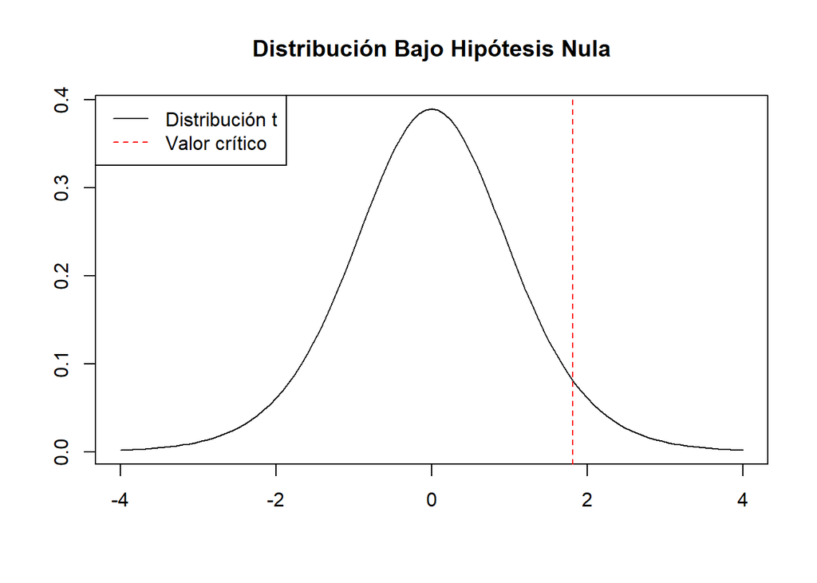

```r
# Definición de los grados de libertad y significancia
df <- 10
alpha <- 0.05

# Distribución t
curve(dt(x, df = df),
      from = -4, to = 4,
      main = "Distribución Bajo Hipótesis Nula",
      xlab = "", ylab = "")

# Valor crítico
abline(v = qt(1 - alpha, df),
       col = "red", lty = 2, add = TRUE)

# Legend
legend(x = "topleft",
       col = c("black", "red"), lty = c(1, 2),
       legend = c("Distribución t", "Valor crítico"))
```

### 5.2.3. Prueba de Cola Izquierda

Consideremos la siguiente prueba:
$$\begin{align*}
H_0: &\: \beta_j = 0 \\
H_1: &\: \beta_j < 0 \\
\end{align*}$$

Encontrar una *regla de decisión* para rechazar la hipótesis nula en este caso es simple:

1. Debemos decidir un nivel de **significancia**, $\alpha$.
2. Buscar un valor de $t_{\hat{\beta}_j}$ lo “suficientemente pequeño” como para rechazar $H_0$ en favor de $H_1$.
3. El valor “suficientemente pequeño” con un nivel de significancia del $100 \alpha$% está dado por el $100(1 - \alpha)$-ésimo percentil de una distribución $t$ con $n-k-1$ grados de libertad.
4. Se rechaza $H_0$ en favor de $H_1$ con una significancia del $100 \alpha$% si
   $$t_{\hat{\beta}_j} < -c$$

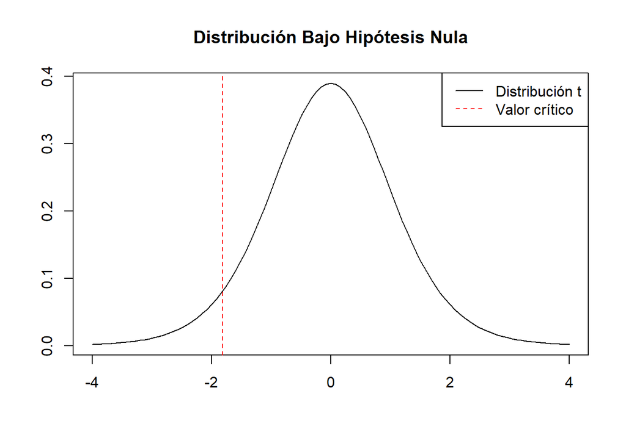

```r
# Definición de los grados de libertad y significancia
df <- 10
alpha <- 0.05

# Distribución t
curve(dt(x, df = df),
      from = -4, to = 4,
      main = "Distribución Bajo Hipótesis Nula",
      xlab = "", ylab = "")

# Valor crítico
abline(v = -qt(1 - alpha, df),
       col = "red", lty = 2, add = TRUE)

# Legend
legend(x = "topright",
       col = c("black", "red"), lty = c(1, 2),
       legend = c("Distribución t", "Valor crítico"))
```

### 5.2.4. Prueba de Dos Colas

Consideremos la siguiente prueba:
$$\begin{align*}
H_0: &\: \beta_j = 0 \\
H_1: &\: \beta_j \neq 0 \\
\end{align*}$$

Encontrar una *regla de decisión* para rechazar la hipótesis nula en este caso es simple:

1. Debemos decidir un nivel de **significancia**, $\alpha$.
2. Buscar un valor de $t_{\hat{\beta}_j}$ lo “suficientemente extremo” como para rechazar $H_0$ en favor de $H_1$.
3. El valor “suficientemente extremo” con un nivel de significancia del $100 \alpha$% está dado por el $100(1 - \frac{\alpha}{2})$-ésimo percentil de una distribución $t$ con $n-k-1$ grados de libertad.
4. Se rechaza $H_0$ en favor de $H_1$ con una significancia del $100 \alpha$% si
   $$| t_{\hat{\beta}_j} | > c$$

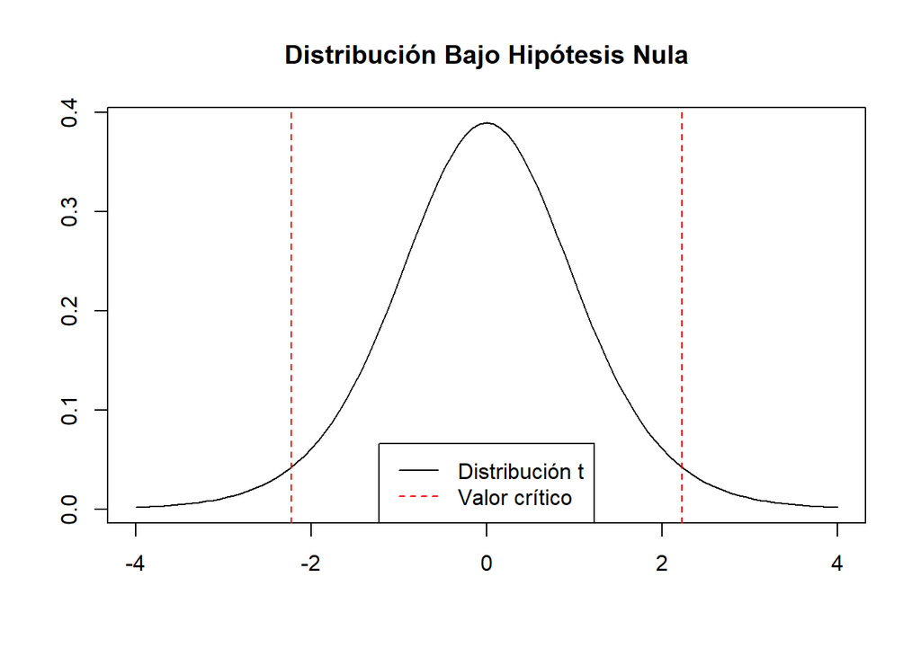

```r
# Definición de los grados de libertad y significancia
df <- 10
alpha <- 0.05

# Distribución t
curve(dt(x, df = df),
      from = -4, to = 4,
      main = "Distribución Bajo Hipótesis Nula",
      xlab = "", ylab = "")

# Valor crítico
abline(v = qt(1 - (alpha / 2), df),
       col = "red", lty = 2, add = TRUE)
abline(v = -qt(1 - (alpha / 2), df),
       col = "red", lty = 2, add = TRUE)

# Legend
legend(x = "bottom",
       col = c("black", "red"), lty = c(1, 2),
       legend = c("Distribución t", "Valor crítico"))
```

### 5.2.5. Hipótesis más Generales

Aunque la hipótesis $H_0: \beta_j = 0$ es la más común, a veces es necesario realizar una prueba en la que $\beta_j$ es igual a otra constante:
$$H_0 \: \beta_j = a_j$$
donde $a_j$ es el valor que creemos que $\beta_j$ tiene.

En estos casos el estadístico de prueba apropiado es:
$$t_{\hat{\beta}_j} = \frac{\hat{\beta}_j -
a_j}{\mathrm{se}(\hat{\beta}_j)}$$

Notemos que **lo único que cambia es el cálculo del estadístico**. La manera de obtener el valor crítico $c$ no cambia.

### 5.2.6. Valor-$p$ de la Prueba $t$

Hasta ahora hemos seguido el *enfoque clásico* de las pruebas de hipótesis: después de haber enunciado una hipótesis alternativa, elegimos un nivel de significancia que sirve para determinar el valor crítico de la prueba. Una vez obtenido el valor crítico, se compara con el estadístico $t$ y se rechaza, o no, la hipótesis nula.

Observemos que en este proceso existe un poco de arbitrariedad, resultado de elegir el nivel de significancia previo a realizar la prueba.

Ante esto, existe un enfoque alternativo que surge de una pregunta simple: *dado el valor del estadístico* $t$*, ¿cuál es nivel de significancia mínimo al que se podría rechazar la hipótesis nula?* A ese nivel de significancia se le llama **valor-$p$** de la prueba.

De esta manera, ante la hipótesis nula $H_0: \: \beta_j = 0$, se define el valor-$p$ como:
$$\mathbb{P}[| \mathcal{T} | > | t |]$$
donde $\mathcal{T}$ denota la distribución de una variable aleatoria que se distribuye $t$ con $n-k-1$ grados de libertad, mientras que $t$ es el estadístico $t_{\hat{\beta}_k}$.

De esta definición es fácil concluir que el valor-$p$ describe que tanta evidencia empírica se tiene en contra de la hipótesis nula: el valor-$p$ es la probabilidad de observar un estadístico $t$ tan “extremo” como el obtenido, suponiendo que la hipótesis nula es cierta. Debido a esto, un valor-$p$ “pequeño” es evidencia en contra de $H_0$.

## 5.3. Intervalos de Confianza

Bajos los supuestos CLM, construir **intervalos de confianza** para los parámetros poblacionales $\beta_j$ es muy sencillo.

El intervalo de confianza de $\beta_j$ está dado por:
$$\hat{\beta}_j \pm c \:
\mathrm{se}(\hat{\beta}_j)$$
Una vez que tenemos el intervalo de confianza es muy sencillo realizar pruebas de dos colas. Si la hipótesis nula es $H_0: \: \beta_j = a_j$, entonces rechazamos $H_0$ en favor de $H_1: \: \beta_j \neq a_j$ al nivel de significancia $100 \alpha$% si y sólo si $a_j$ no está contenido en el intervalo.

Un comentario importante sobre los intervalos de confianza: los intervalos de confianza se obtienen de una muestra aleatoria de la población, lo que significa que cada muestra obtenida resultará en cotas superior e inferior distintas del intervalo. Lo que los intervalos de confianza quieren decir es que, si repetimos este proceso varias veces, entonces el valor del parámetro poblacional $\beta_j$ estará contenido en el $100 (1 - \alpha)$% de los intervalos que hayamos construido. Naturalmente, para la muestra particular que estamos usando, no podemos saber si $\beta_j$ está contenido en el intervalo calculado.

## 5.4. Prueba $F$

En ocasiones se desea realizar pruebas sobre un *conjunto* de variables para determinar si tienen, o no, un efecto sobre la variable dependiente.

Este tipo de pruebas se pueden escribir como:
$$\begin{align*}
H_0: &\: \beta_j = \beta_l = \beta_m = 0 \\
H_1: &\: H_0 \text{ no es verdadera}
\end{align*}$$

Al ver la prueba, se podría concluir (erróneamente) que basta con realizar el análisis individual de los respectivos estadísticos $t$. Esta conclusión es errónea porque lo que se busca es una prueba que verifique de manera **conjunta** la significancia de las variables de interés.

Suponga que se tiene un modelo con $k$ variables independientes:
$$y = \beta_0 + \beta_1 x_1 + \beta_2 x_2 + ... +
\beta_k x_k + u$$
A este modelo lo llamaremos **modelo no restringido**.

Supongamos que se tienen $q$ restricciones, es decir, creemos que hay $q$ variables independientes que, de manera conjunta, no tienen efecto sobre $y$. Por simplicidad de notación, supongamos que son las últimas $q$ variables las que se desea excluir:
$$H_0: \: \beta_{k-q+1} = ... = \beta_k = 0$$
Bajo la hipótesis nula el modelo se podría expresar como:
$$y = \beta_0 + \beta_1 x_1 + \beta_2 x_2 +
... + \beta_{k-q} x_{k-q} + u$$
A este modelo lo llamaremos **modelo restringido**.

La idea de la prueba gira entorno a que tanto incrementa $SSR$ cuando se excluyen las $q$ variables explicativas de interés. El estadístico que nos permite medir esto es el **estadístico** $F$:
$$F = \frac{(SSR_r - SSR_{ur}) / q}{SSR_{ur}
/ (n-k-1)}$$
Este estadístico sigue una distribución $F$ con $(q, n-k-1)$ grados de libertad:
$$F \sim
F_{q, n-k-1}$$
Al igual que con la prueba $t$, $H_0$ se rechaza en favor de $H_1$ cuando el valor de estadístico es muy “extremo” como para provenir de la distribución que sugiere $H_0$:
$$F >
c$$
donde $c$ es el valor crítico que corresponde al $100(1-\alpha)$-ésimo percentil de la distribución $F$ con los grados de libertad especificados:

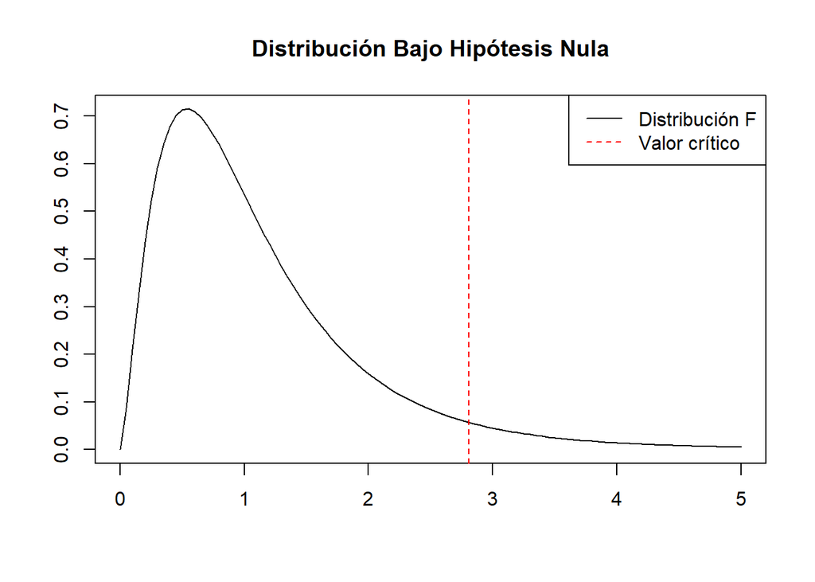

```r
# Definición de los grados de libertad y significancia
q <- 5
df <- 17
alpha <- 0.05

# Distribución F
curve(df(x, df1 = q, df2 = df),
      from = 0, to = 5,
      main = "Distribución Bajo Hipótesis Nula",
      xlab = "", ylab = "")

# Valor crítico
abline(v = qf(1 - alpha, q, df),
       col = "red", lty = 2, add = TRUE)

# Legend
legend(x = "topright",
       col = c("black", "red"), lty = c(1, 2),
       legend = c("Distribución F", "Valor crítico"))
```

Una manera más sencilla de calcular el estadístico $F$ es:
$$F =
\frac{(R_r^2 - R_{ur}^2) / q}{(1 - R_{ur}^2)/(n-k-1)}$$

### 5.4.1. Valor-$p$ de la Prueba $F$

Para las pruebas conjuntas, el valor-$p$ está definido como:
$$\mathbb{P}[\mathcal{F} > F]$$
donde $\mathcal{F}$ es una variable aleatoria distribuida $F$ con $(q, n-k-1)$ grados de libertad, y $F$ es el valor del estadístico de la prueba.

Notemos que, por la definición, este valor-$p$ tiene la misma interpretación (y uso) que el valor-$p$ de la prueba $t$.

### 5.4.2. Prueba de Significancia Global de la Regresión

Existe una prueba de exclusión que resulta muy importante:
$$H_0: \: \beta_1 = \beta_2 = ... = \beta_k = 0$$
Esta hipótesis nula es muy pesimista pues afirma que ninguna de las variables explicativas tiene efecto (conjunto) sobre $y$. Esto resulta en el siguiente modelo restringido:
$$y = \beta_0 + u$$
que, naturalmente, tiene $R^2 = 0$. Por tanto, el estadístico de esta prueba, conocida como la **prueba de significancia global** es:
$$F =
\frac{R^2 \: / \: k}{(1 - R^2) \: / \: (n - k - 1)}$$

donde $R^2$ es el coeficiente de determinación de la regresión de $y$ en $x_1, x_2, ..., x_k$.

## 5.5. Ejemplos

Veamos algunos ejemplos de los conceptos cubiertos.

### 5.5.1. Pruebas $t$ cuando $H_0: \: \beta_j = 0$

Estamos interesados en entender los determinantes del desempeño escolar de estudiantes de licenciatura. Para realizar este análisis, tomaremos como variable dependiente al promedio escolar (`colGPA`) y como variables explicativas se considerarán:

- `hsGPA`: promedio de la preparatoria.  
  Esperamos que esta variable tenga una relación positiva con la variable a explicar.
- `ACT`: calificación en una evaluación de habilidades/logros.  
  Esta evaluación tuvo sus defectos de diseño, por lo que no sabemos con certeza cual pueda ser la relación que tenga con el promedio de la licenciatura.
- `skipped`: promedio de inasistencias semanales a clases.  
  Esperamos que esta variable tenga un efecto negativo sobre la variable a explicar.

De esta manera, el modelo que se desea estimar es:
$$colGPA = \beta_0 + \beta_1 \: hsGPA + \beta_2 \:
ACT + \beta_3 \: skipped + u$$

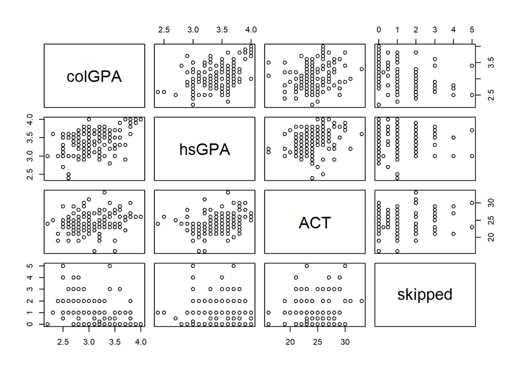

```r
# Carga de datos
data(gpa1)

# Seleccion de variables relevantes
base1 <- gpa1 %>%
  select(colGPA, hsGPA, ACT, skipped)

# Analisis grafico preliminar
plot(base1)
```

```r
# Estimacion del modelo
modelo_promedio_univ <- lm(formula = colGPA ~ hsGPA + ACT + skipped,
                           data = base1)

# Presentacion de los resultados
stargazer(modelo_promedio_univ, digits = 3,
          type = "text", style = "aer",
          dep.var.labels = c("Promedio Univ"),
          covariate.labels = c("Promedio Prepa",
                               "Habilidades/Logros",
                               "Inasistencia",
                               "Constante"),
          keep.stat = c("n", "rsq", "f"))
```

```
##
## =========================================================
##                                Promedio Univ
## ---------------------------------------------------------
## Promedio Prepa                    0.412***
##                                   (0.094)
##
## Habilidades/Logros                 0.015
##                                   (0.011)
##
## Inasistencia                     -0.083***
##                                   (0.026)
##
## Constante                         1.390***
##                                   (0.332)
##
## Observations                        141
## R2                                 0.234
## F Statistic               13.919*** (df = 3; 137)
## ---------------------------------------------------------
## Notes:             ***Significant at the 1 percent level.
##                    **Significant at the 5 percent level.
##                    *Significant at the 10 percent level.
```

Ya que tenemos estimado el modelo podemos realizar las pruebas que nos son de interés y que se mencionaron anteriormente. Primero:
$$\begin{align*}
H_0: &\: \beta_1 = 0 \\
H_0: &\: \beta_1 > 0 \\
\end{align*}$$

Para poder probar nuestra primera hipótesis necesitamos construir el estadístico de prueba adecuado:

```r
# Elementos necesarios para el calculo del estadistico t
beta_hsgpa <- summary(modelo_promedio_univ)$coefficients[2, 1]
se_hsgpa <- summary(modelo_promedio_univ)$coefficients[2, 2]

# Calculo del estadistico
t_hsgpa <- beta_hsgpa / se_hsgpa
t_hsgpa
```

```
## [1] 4.39626
```

Ahora que tenemos el estadístico de prueba, nos falta encontrar los valores críticos dependiendo del nivel de significancia deseado. En la práctica el nivel de significancia es único y se determina de antemano. Aquí trabajaremos con los tres niveles de significancia más comunes para ver cómo cambia la conclusión de la prueba con cada uno:

```r
# Parametros globales de la prueba
n <- nobs(modelo_promedio_univ)
k <- 3
df <- n - k - 1

# Valores criticos
val_criticos <- c(qt(1 - 0.10, df),
                  qt(1 - 0.05, df),
                  qt(1 - 0.01, df))
val_criticos
```

```
## [1] 1.287762 1.656052 2.353875
```

De esta manera podemos obtener las siguientes conclusiones:

```r
# Conclusion al 10%
if (t_hsgpa > val_criticos[1]){
  print("Se rechaza H0 en favor de H1 al 10% de significancia")
} else{
  print("No se rechaza H0 al 10% de significancia")
}
```

```
## [1] "Se rechaza H0 en favor de H1 al 10% de significancia"
```

```r
# Conclusion al 5%
if (t_hsgpa > val_criticos[2]){
  print("Se rechaza H0 en favor de H1 al 5% de significancia")
} else{
  print("No se rechaza H0 al 5% de significancia")
}
```

```
## [1] "Se rechaza H0 en favor de H1 al 5% de significancia"
```

```r
# Conclusion al 1%
if (t_hsgpa > val_criticos[3]){
  print("Se rechaza H0 en favor de H1 al 1% de significancia")
} else{
  print("No se rechaza H0 al 1% de significancia")
}
```

```
## [1] "Se rechaza H0 en favor de H1 al 1% de significancia"
```

Aunque estas conclusiones son correctas desde el punto de vista técnico, tienen la desventaja de que pueden ser manipulables por la arbitrariedad que existe al determinar el nivel de significancia deseado. Para evitar esa arbitrariedad podemos usar el valor-$p$ de la prueba.

```r
# Calculo del valor p
p_val_der <- pt(-t_hsgpa, df)
p_val_der
```

```
## [1] 1.096025e-05
```

Este valor-$p$ indica que el nivel mínimo de significancia al que se pude rechazar $H_0$ es 0.001096% de significancia, o dicho de otra manera. Rechazamos $H_0$ con una “confianza” del 99.9989%.

La segunda prueba que queremos realizar es:
$$\begin{align*}
H_0: &\: \beta_3 = 0 \\
H_0: &\: \beta_3 < 0 \\
\end{align*}$$

Para poder probar la segunda hipótesis necesitamos construir el estadístico de prueba adecuado:

```r
# Elementos necesarios para el calculo del estadistico t
beta_skip <- summary(modelo_promedio_univ)$coefficients[4, 1]
se_skip <- summary(modelo_promedio_univ)$coefficients[4, 2]

# Calculo del estadistico
t_skip <- beta_skip / se_skip
t_skip
```

```
## [1] -3.19684
```

Calculamos los valores críticos (no cambian con respecto de la prueba de cola derecha):

```r
# Valores criticos
val_criticos <- c(qt(1 - 0.10, df),
                  qt(1 - 0.05, df),
                  qt(1 - 0.01, df))
val_criticos
```

```
## [1] 1.287762 1.656052 2.353875
```

De esta manera podemos obtener las siguientes conclusiones:

```r
# Conclusion al 10%
if (t_skip < -val_criticos[1]){
  print("Se rechaza H0 en favor de H1 al 10% de significancia")
} else{
  print("No se rechaza H0 al 10% de significancia")
}
```

```
## [1] "Se rechaza H0 en favor de H1 al 10% de significancia"
```

```r
# Conclusion al 5%
if (t_skip < -val_criticos[2]){
  print("Se rechaza H0 en favor de H1 al 5% de significancia")
} else{
  print("No se rechaza H0 al 5% de significancia")
}
```

```
## [1] "Se rechaza H0 en favor de H1 al 5% de significancia"
```

```r
# Conclusion al 1%
if (t_skip < -val_criticos[3]){
  print("Se rechaza H0 en favor de H1 al 1% de significancia")
} else{
  print("No se rechaza H0 al 1% de significancia")
}
```

```
## [1] "Se rechaza H0 en favor de H1 al 1% de significancia"
```

Con el enfoque del valor-$p$:

```r
# Calculo del valor p
p_val_izq <- pt(t_skip, df)
p_val_izq
```

```
## [1] 0.0008627156
```

Este valor-$p$ indica que el nivel mínimo de significancia al que se pude rechazar $H_0$ al 0.086272% de significancia, o dicho de otra manera. Rechazamos $H_0$ con una “confianza” del 99.91373%.

La tercer (y última) prueba que queremos realizar es:
$$\begin{align*}
H_0: &\: \beta_2 = 0 \\
H_0: &\: \beta_2 \neq 0 \\
\end{align*}$$

Para poder probar la última hipótesis necesitamos construir el estadístico de prueba adecuado:

```r
# Elementos necesarios para el calculo del estadistico t
beta_act <- summary(modelo_promedio_univ)$coefficients[3, 1]
se_act <- summary(modelo_promedio_univ)$coefficients[3, 2]

# Calculo del estadistico
t_act <- beta_act / se_act
t_act
```

```
## [1] 1.393319
```

Calculamos los valores críticos (ahora si cambian con respecto de las pruebas de colas derecha e izquierda):

```r
# Valores criticos
val_criticos <- c(qt(1 - (0.10 / 2), df),
                  qt(1 - (0.05 / 2), df),
                  qt(1 - (0.01 / 2), df))
val_criticos
```

```
## [1] 1.656052 1.977431 2.612192
```

De esta manera podemos obtener las siguientes conclusiones:

```r
# Conclusion al 10%
if (abs(t_act) > val_criticos[1]){
  print("Se rechaza H0 en favor de H1 al 10% de significancia")
} else{
  print("No se rechaza H0 al 10% de significancia")
}
```

```
## [1] "No se rechaza H0 al 10% de significancia"
```

```r
# Conclusion al 5%
if (abs(t_act) > val_criticos[2]){
  print("Se rechaza H0 en favor de H1 al 5% de significancia")
} else{
  print("No se rechaza H0 al 5% de significancia")
}
```

```
## [1] "No se rechaza H0 al 5% de significancia"
```

```r
# Conclusion al 1%
if (abs(t_act) > val_criticos[3]){
  print("Se rechaza H0 en favor de H1 al 1% de significancia")
} else{
  print("No se rechaza H0 al 1% de significancia")
}
```

```
## [1] "No se rechaza H0 al 1% de significancia"
```

Esta prueba también se prodía realizar con los intervalos de confianza:

```r
# Intervalo 90%
lower_90 <- beta_act - val_criticos[1] * se_act
upper_90 <- beta_act + val_criticos[1] * se_act
print(paste0("El intervalo de confianza del 90% es: (",
             round(lower_90, 3), ",",
             round(upper_90, 3), ")"))
```

```
## [1] "El intervalo de confianza del 90% es: (-0.003,0.032)"
```

```r
if (beta_act > lower_90 & beta_act < upper_90){
  print("No se rechaza H0")
}else{
  print("Se rechaza H0")
}
```

```
## [1] "No se rechaza H0"
```

```r
# Intervalo 95%
lower_95 <- beta_act - val_criticos[2] * se_act
upper_95 <- beta_act + val_criticos[2] * se_act
print(paste0("El intervalo de confianza del 95% es: (",
             round(lower_95, 3), ",",
             round(upper_95, 3), ")"))
```

```
## [1] "El intervalo de confianza del 95% es: (-0.006,0.036)"
```

```r
if (beta_act > lower_90 & beta_act < upper_90){
  print("No se rechaza H0")
}else{
  print("Se rechaza H0")
}
```

```
## [1] "No se rechaza H0"
```

```r
# Intervalo 99%
lower_99 <- beta_act - val_criticos[3] * se_act
upper_99 <- beta_act + val_criticos[3] * se_act
print(paste0("El intervalo de confianza del 99% es: (",
             round(lower_99, 3), ",",
             round(upper_99, 3), ")"))
```

```
## [1] "El intervalo de confianza del 99% es: (-0.013,0.042)"
```

```r
if (beta_act > lower_90 & beta_act < upper_90){
  print("No se rechaza H0")
}else{
  print("Se rechaza H0")
}
```

```
## [1] "No se rechaza H0"
```

Con el enfoque del valor-$p$:

```r
# Calculo del valor p
p_val <- 2 * pt(-abs(t_act), df)
p_val
```

```
## [1] 0.1657799
```

Este valor-$p$ indica que el nivel mínimo de significancia al que se pude rechazar $H_0$ al 16.578% de significancia, o dicho de otra manera. Rechazamos $H_0$ con una “confianza” del 83.42201%.

### 5.5.2. Pruebas $t$ cuando $H_0: \: \beta_j = a_j$

Suponga que estamos interesados en saber cómo es que ciertas características de una comunidad afectan al precio (mediano) de las casas. En particular nos interesa saber la relación que tiene este precio con las siguientes variables:

- `nox`: cantidad de óxido de nitrógeno (contaminante) en el aire (medido en ppm).
- `dist`: distancia de la comunidad a los centros de trabajo.
- `rooms`: número promedio de habitaciones en las casas.
- `stratio`: proporción de estudiantes a docentes que hay en las escuelas de la comunidad.

El modelo que se propone estudiar es el siguiente:
$$\ln(price) = \beta_0 + \beta_1 \: \ln(nox) +
\beta_2 \ln(dist) + \beta_3 \: rooms + \beta_4 \: stratio$$
En particular nos interesa la elasticidad del precio mediano de las casas con respecto de la contaminación del aire que existe. Esto es:
$$\begin{align*}
H_0: &\: \beta_1 = -1 \\
H_1: &\: \beta_1 \neq -1
\end{align*}$$

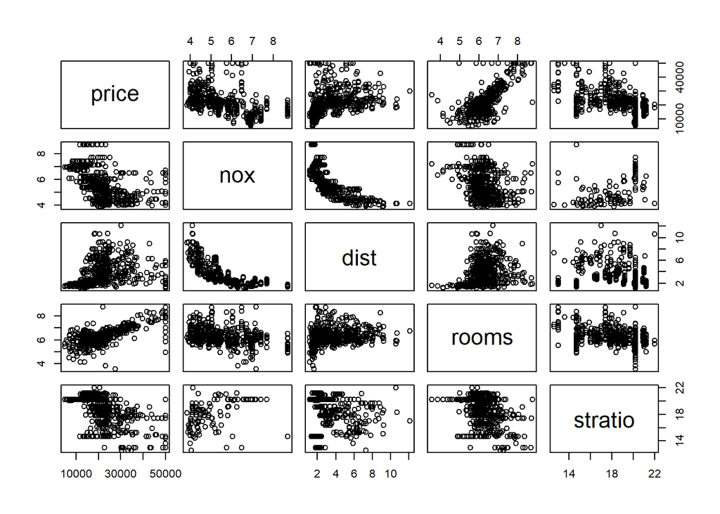

```r
# Carga de datos
data(hprice2)

# Seleccion de variables relevantes
base2 <- hprice2 %>%
  select(price, nox, dist, rooms, stratio)

# Analisis grafico preliminar
plot(base2)
```

```r
# Estimacion del modelo
modelo_precio_casas <- lm(formula = log(price) ~ log(nox) + log(dist) + rooms + stratio,
                            data = base2)

# Presentacion de los resultados
stargazer(modelo_precio_casas, digits = 3,
          type = "text", style = "aer",
          dep.var.labels = c("Precio"),
          covariate.labels = c("Contaminación", "Distancia",
                               "Habitaciones",
                               "Estudiates/Docentes",
                               "Constante"),
          keep.stat = c("n", "rsq", "f"))
```

```
##
## ==========================================================
##                                     Precio
## ----------------------------------------------------------
## Contaminación                     -0.954***
##                                    (0.117)
##
## Distancia                         -0.134***
##                                    (0.043)
##
## Habitaciones                       0.255***
##                                    (0.019)
##
## Estudiates/Docentes               -0.052***
##                                    (0.006)
##
## Constante                         11.084***
##                                    (0.318)
##
## Observations                         506
## R2                                  0.584
## F Statistic                175.855*** (df = 4; 501)
## ----------------------------------------------------------
## Notes:              ***Significant at the 1 percent level.
##                     **Significant at the 5 percent level.
##                     *Significant at the 10 percent level.
```

Para poder probar nuestra hipótesis necesitamos construir el estadístico de prueba adecuado:

```r
# Elementos necesarios para el calculo del estadistico t
beta_nox <- summary(modelo_precio_casas)$coefficients[2, 1]
se_nox <- summary(modelo_precio_casas)$coefficients[2, 2]
val_hip <- -1

# Calculo del estadistico
t_nox <- (beta_nox - val_hip) / se_nox
t_nox
```

```
## [1] 0.3979852
```

Ahora que tenemos el estadístico de prueba, nos falta encontar los valores críticos dependiendo del nivel de significancia deseado. En la práctica el nivel de significancia es único y se determina de antemano. Aquí trabajaremos con los tres niveles de significancia más comunes para ver cómo cambia la conclusión de la prueba con cada uno:

```r
# Parametros globales de la prueba
n <- nobs(modelo_precio_casas)
k <- 4
df <- n - k - 1

# Valores criticos
val_criticos <- c(qt(1 - (0.10 / 2), df),
                  qt(1 - (0.05 / 2), df),
                  qt(1 - (0.01 / 2), df))
val_criticos
```

```
## [1] 1.647901 1.964710 2.585678
```

De esta manera podemos obtener las siguientes conclusiones:

```r
# Conclusion al 10%
if (abs(t_nox) > val_criticos[1]){
  print("Se rechaza H0 en favor de H1 al 10% de significancia")
} else{
  print("No se rechaza H0 al 10% de significancia")
}
```

```
## [1] "No se rechaza H0 al 10% de significancia"
```

```r
# Conclusion al 5%
if (abs(t_nox) > val_criticos[2]){
  print("Se rechaza H0 en favor de H1 al 5% de significancia")
} else{
  print("No se rechaza H0 al 5% de significancia")
}
```

```
## [1] "No se rechaza H0 al 5% de significancia"
```

```r
# Conclusion al 1%
if (abs(t_nox) > val_criticos[3]){
  print("Se rechaza H0 en favor de H1 al 1% de significancia")
} else{
  print("No se rechaza H0 al 1% de significancia")
}
```

```
## [1] "No se rechaza H0 al 1% de significancia"
```

Esta misma conclusión se pudo haber obtenido usando los intervalos de confianza:

```r
# Intervalo 90%
lower_90 <- beta_nox - val_criticos[1] * se_nox
upper_90 <- beta_nox + val_criticos[1] * se_nox
print(paste0("El intervalo de confianza del 90% es: (",
             round(lower_90, 3), ",",
             round(upper_90, 3), ")"))
```

```
## [1] "El intervalo de confianza del 90% es: (-1.146,-0.761)"
```

```r
# Intervalo 95%
lower_95 <- beta_nox - val_criticos[2] * se_nox
upper_95 <- beta_nox + val_criticos[2] * se_nox
print(paste0("El intervalo de confianza del 95% es: (",
             round(lower_95, 3), ",",
             round(upper_95, 3), ")"))
```

```
## [1] "El intervalo de confianza del 95% es: (-1.183,-0.724)"
```

```r
# Intervalo 99%
lower_99 <- beta_nox - val_criticos[3] * se_nox
upper_99 <- beta_nox + val_criticos[3] * se_nox
print(paste0("El intervalo de confianza del 99% es: (",
             round(lower_99, 3), ",",
             round(upper_99, 3), ")"))
```

```
## [1] "El intervalo de confianza del 99% es: (-1.255,-0.652)"
```

Usando el enfoque del valor-$p$ tenemos:

```r
p_val <- 2 * pt(-abs(t_nox), df)
p_val
```

```
## [1] 0.6908106
```

Este valor-$p$ indica que el nivel mínimo de significancia al que se pude rechazar $H_0$ al 69.08% de significancia, o dicho de otra manera. Rechazamos $H_0$ con una “confianza” del 30.92%.

### 5.5.3. Prueba $F$

Suponga que estamos interesados en analizar el desempeño de jugadores de baseball y la relación que este tiene con su salario.

Para realizar el análisis, además del salario (`salary`), se deciden usar las siguientes variables explicativas:

- `years`: antigüedad del jugador en las ligas mayores.
- `gamesyr`: juegos en los que participa por año.
- `bavg`: promedio de bateo.
- `hrunyr`: home runs producidos en el año.
- `rbisyr`: carreras producidas en el año.

De esta forma, la ecuación propuesta es:
$$salary = \beta_0 + \beta_1 \: years + \beta_2 \:
gamesyr + \beta_3 \: bavg + \beta_4 \: hrnyr + \beta_5 \: rbisyr +
u$$

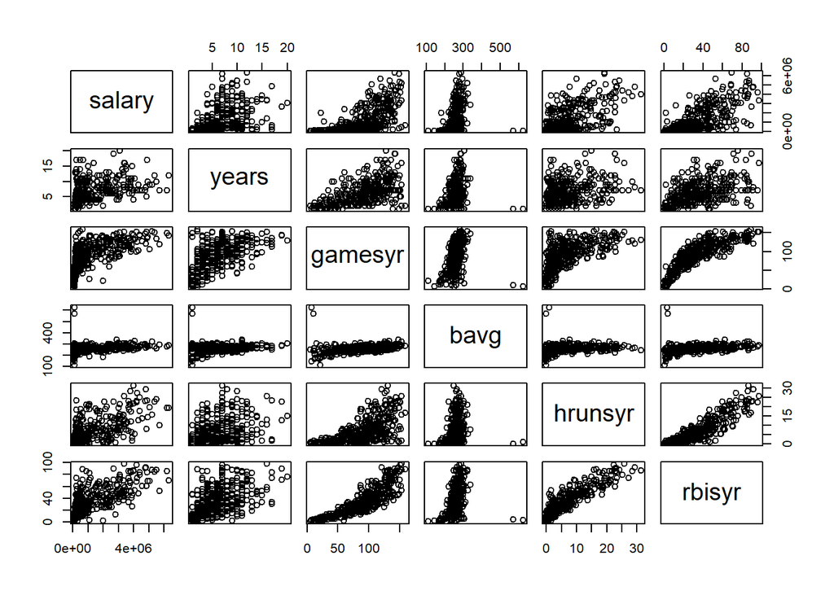

```r
# Carga de datos
data(mlb1)

# Seleccion de variables relevantes
base3 <- mlb1 %>%
  select(salary, years, gamesyr, bavg, hrunsyr, rbisyr)

# Analisis grafico preliminar
plot(base3)
```

```r
# Estimacion del modelo
modelo_baseball_nores <- lm(formula = salary ~ years + gamesyr + bavg + hrunsyr + rbisyr,
                            data = base3)

# Presentacion de los resultados
stargazer(modelo_baseball_nores, digits = 3,
          type = "text", style = "aer",
          dep.var.labels = c("Salario"),
          covariate.labels = c("Antigüedad", "Juegos/año",
                               "Promedio Bateo", "HR/año",
                               "RBIS/año", "Constante"),
          keep.stat = c("n", "rsq", "f"))
```

```
##
## =====================================================
##                               Salario
## -----------------------------------------------------
## Antigüedad                 60,629.290***
##                             (16,255.030)
##
## Juegos/año                   2,253.742
##                             (3,551.369)
##
## Promedio Bateo               2,029.755
##                             (1,480.664)
##
## HR/año                       17,891.900
##                             (21,544.900)
##
## RBIS/año                   29,699.640***
##                             (9,627.206)
##
## Constante                  -934,892.900**
##                            (387,536.200)
##
## Observations                    353
## R2                             0.527
## F Statistic           77.308*** (df = 5; 347)
## -----------------------------------------------------
## Notes:         ***Significant at the 1 percent level.
##                **Significant at the 5 percent level.
##                *Significant at the 10 percent level.
```

Al ver los resultados, un analista nos comenta que, en su expriencia, las métricas de desempeño como `bavg`, `hrunsyr` y `rbis` no son tan importantes como la antigüedad y los juegos por año del jugador. Para aprovechar la experiencia del analista, procedemos a evaluar su propuesta. Esto es, queremos realizar la prueba:
$$\begin{align*}
H_0: &\: \beta_3 = \beta_4 = \beta_5 = 0 \\
H_1: &\: H_0 \text{ no es correcta}
\end{align*}$$

Esta prueba requiere de la estimación del modelo restringido:

```r
# Estimacion del modelo restringido
modelo_baseball_res <- lm(formula = salary ~ years + gamesyr,
                          data = base3)

# Presentacion de los resultados
stargazer(modelo_baseball_nores,
          modelo_baseball_res, digits = 3,
          type = "text", style = "aer",
          dep.var.labels = c("Salario"),
          covariate.labels = c("Antigüedad", "Juegos/año",
                               "Promedio Bateo", "HR/año",
                               "RBIS/año", "Constante"),
          keep.stat = c("n", "rsq", "f"))
```

```
##
## ===============================================================
##                                    Salario
##                          (1)                     (2)
## ---------------------------------------------------------------
## Antigüedad          60,629.290***           65,267.060***
##                     (16,255.030)             (17,843.290)
##
## Juegos/año            2,253.742             20,652.950***
##                      (3,551.369)             (1,916.129)
##
## Promedio Bateo        2,029.755
##                      (1,480.664)
##
## HR/año               17,891.900
##                     (21,544.900)
##
## RBIS/año            29,699.640***
##                      (9,627.206)
##
## Constante          -934,892.900**          -927,529.200***
##                     (387,536.200)           (154,549.500)
##
## Observations             353                     353
## R2                      0.527                   0.421
## F Statistic    77.308*** (df = 5; 347) 127.173*** (df = 2; 350)
## ---------------------------------------------------------------
## Notes:         ***Significant at the 1 percent level.
##                **Significant at the 5 percent level.
##                *Significant at the 10 percent level.
```

Simplemente comparar los modelos no nos dice nada sobre la pertinencia de mantener (o no) las variables `bavg`, `hrunsyr` y `rbis` en el modelo. Para poder responder esa pregunta de manera rigurosa debemos realizar la prueba $F$:

```r
# Elementos necesarios para el calculo del estadistico F
ssr_nores <- sum(modelo_baseball_nores$residuals^2)
ssr_res <- sum(modelo_baseball_res$residuals^2)
n <- nobs(modelo_baseball_nores)
k <- 5
q <- 3

# Calculo el estadistico F
f_stat <- ((ssr_res - ssr_nores) / ssr_nores) * ((n - k -1) / q)
f_stat
```

```
## [1] 25.93995
```

Este estadístico también se puede calcular en su versión de $R^2$:

```r
# Elementos necesarios para el calculo del estadistico F
r2_nores <- summary(modelo_baseball_nores)$r.squared
r2_res <- summary(modelo_baseball_res)$r.squared
n <- nobs(modelo_baseball_nores)
k <- 5
q <- 3

# Calculo el estadistico F
f_stat_r2 <- ((r2_nores - r2_res) / (1 - r2_nores)) * ((n - k - 1) / q)
f_stat_r2
```

```
## [1] 25.93995
```

Ahora que tenemos el estadístico de prueba, nos falta encontar los valores críticos dependiendo del nivel de significancia deseado. En la práctica el nivel de significancia es único y se determina de antemano. Aquí trabajaremos con los tres niveles de significancia más comunes para ver cómo cambia la conclusión de la prueba con cada uno:

```r
# Valores criticos
val_criticos <- c(qf(1 - 0.10, q, n - k - 1),
                  qf(1 - 0.05, q, n - k - 1),
                  qf(1 - 0.01, q, n - k - 1))
val_criticos
```

```
## [1] 2.099635 2.630641 3.838520
```

De esta manera podemos obtener las siguientes conclusiones:

```r
# Conclusion al 10%
if (f_stat > val_criticos[1]){
  print("Se rechaza H0 en favor de H1 al 10% de significancia")
} else{
  print("No se rechaza H0 al 10% de significancia")
}
```

```
## [1] "Se rechaza H0 en favor de H1 al 10% de significancia"
```

```r
# Conclusion al 5%
if (f_stat > val_criticos[2]){
  print("Se rechaza H0 en favor de H1 al 5% de significancia")
} else{
  print("No se rechaza H0 al 5% de significancia")
}
```

```
## [1] "Se rechaza H0 en favor de H1 al 5% de significancia"
```

```r
# Conclusion al 1%
if (f_stat > val_criticos[3]){
  print("Se rechaza H0 en favor de H1 al 1% de significancia")
} else{
  print("No se rechaza H0 al 1% de significancia")
}
```

```
## [1] "Se rechaza H0 en favor de H1 al 1% de significancia"
```

Aunque estas conclusiones son correctas desde el punto de vista técnico, tienen la desventaja de que pueden ser manipulables por la arbitrariedad que existe al determinar el nivel de significancia deseado. Para evitar esa arbitrariedad podemos usar el valor-$p$ de la prueba.

```r
# Calculo del valor p
p_val <- 1 - pf(f_stat, q, n - k - 1)
p_val
```

```
## [1] 3.663736e-15
```

Este valor-$p$ indica que el nivel mínimo de significancia al que se pude rechazar $H_0$ al 0.0000000000003663736% de significancia, o dicho de otra manera. Rechazamos $H_0$ con una “confianza” del 99.9999999999996%.

## 5.6. Ejercicios

1. Considere la base de datos `ceosal1`.
   Se busca explicar el salario de un CEO usando las ventas de la firma, el ROE y el ROS como variables independientes:
   $$\ln(salary) = \beta_0 + \beta_1 \ln(sales) +
   \beta_2 roe + \beta_3 ros + u$$
   1. Estime el modelo indicado. ¿Cuánto incrementa el salario si `ros` incrementa en 50pp? ¿Es este efecto significativo económicamente?
   2. Usando la notación de los parámetros poblacionales, establezca la hipótesis de que, una vez que se controla por `sales` y `roe`, `ros` no tiene efecto sobre el salario del CEO.  
      Establezca la hipótesis alternativa de que `ros` tiene un efecto positivo sobre el salario del CEO.
   3. Usando un nivel de significancia del 10%, realice la prueba de hipótesis indicada en el inciso anterior.
   4. Teniendo en cuenta los resultados del inciso anterior, ¿mantendría a `ros` como un factor dentro del modelo que pretende explicar el salario del CEO en términos de su desempeño? Explique.
2. Considere la base de datos `rental`.
   Se busca establecer si los precios de las rentas son afectados por la cantidad de población estudiantil que hay en una pequeña ciudad. Para hacerlo, se propone el modelo:
   $$\ln(rent) =
   \beta_0 + \beta_1 \ln(pop) + \beta_2 \ln(avginc) + \beta_3 pctstu +
   u$$
   1. Establezca la hipótesis nula de que el tamaño del cuerpo estudiantil no tiene efecto parcial sobre las rentas.  
      Establezca la hipótesis alternativa de que si tiene un efecto.
   2. ¿Qué signos esperaríamos estuvieran asociados a $\beta_1$ y $\beta_2$? Explique.
   3. Estime el modelo. Es correcta la siguiente afirmación:  
      “Un incremento del 10% en la población estudiantil implicaría un incremento del 6.6% en las rentas”. Explique.
   4. Usando un nivel de significancia del 1%, realice la prueba de hipótesis indicada anteriormente.
3. Considere la base de datos `wage2`.
   Se estima el modelo:
   $$\ln(wage) = \beta_0 +
   \beta_1 educ + \beta_2 exper + \beta_3 tenure + u$$
   1. Establezca la hipótesis nula de que un año adicional de experiencia tiene el mismo efecto sobre el salario que un año de antigüedad.
   2. Usando un nivel de significancia del 5%, verifique esta hipótesis contra una alternativa de dos colas.